# IODS-Course Final Assignment

Janne Kirjasniemi

janne.kirjasniemi@gmail.com

March 8, 2017

# Final assignment

## Dataset and variables

For this analysis I have combined data from UN Human Development Report’s Human Development Index(HDI) dataset with data from Gapminder’s datasets, specifically the one’s containing the mean fertility of women in different countries, the rate of deaths in children under five years old per 1000 live births and foreign aid received as a proportion of Gross National Income(GNI), which has been provided to Gapminder by World Bank.

These datasets can be accessed from: http://hdr.undp.org/en/data for Human Development Index data and for Gapminder: https://www.gapminder.org/data/

All in all, this dataset has 159 observation of 17 variables, where the observations are per country, where the data was available from the sources used. In the case of HDI data, the data include averages for education, GNI and HDI value, which is a geometrical mean of the different variables used in the making of the HDI report. There are also many variables concerning the rate of female and male participation in education and labour force or GNI(these are rates of female rate or value divided by male rate or value) as well as variables for maternal mortality and adolescent pregnancies. All of these are for year 2014. From Gapminder are included mortality of children under 5 years old per 1000 live births for the year 2014 and the fertility, that is birthrate of women, for the year 2014.

The last dat from World Bank is foreign aid received by country as a proportion of their GNI. This is presented as a mean of proportions from the year 1984 to 2004, altogether 21 years. THis has been done to get a number for foreign aid received some time before the time in the other data, which is 2014. Also included is a variable for the amount of years the mean was calculated from, to get an idea of the consistency of aid to the country in question. The basic numbers for the countries that received foreign aid are:

```r
summary(hdi.aid$mean04[!is.na(hdi.aid$mean04)])
```

```
##     Min.  1st Qu.   Median     Mean  3rd Qu.     Max.
##  0.01502  1.04400  4.77800  8.87000 12.71000 61.53000
```

```r
summary(hdi.aid$mean.length[hdi.aid$mean.length!=0])
```

```
##    Min. 1st Qu.  Median    Mean 3rd Qu.    Max.
##    1.00   16.50   21.00   18.37   21.00   21.00
```

```r
length(hdi.aid$mean.length[hdi.aid$mean.length!=0])
```

```
## [1] 123
```

Here the upper values are for the aid received and the lower for the amount of years from the 21 year period that there was a value to be had from the data. As one can see, 75% of the observed values for the years of aid received is 16 or more, so the aid has been quite consistent. The lowest value is the number of countries from the observations that received aid during this period.

## Hypothesis or purpose

The purpose of this analysis is to compare the variables of the dataset to some variables of interest. The first of these variables is the fertility of women and the HDI value, summaries of which are here:

```r
summary(hdi.aid$Fert)
```

```
##    Min. 1st Qu.  Median    Mean 3rd Qu.    Max.
##   1.290   1.805   2.300   2.826   3.760   7.540
```

```r
summary(hdi.aid$HDI)
```

```
##    Min. 1st Qu.  Median    Mean 3rd Qu.    Max.
##  0.3483  0.5516  0.7258  0.6909  0.8182  0.9439
```

The factors in question will first be analysed through principal component analysis(PCA) after they have been standardized through scaling.

While the rate of foreign aid is a variable in the dataset and it is interesting to see how it affects the other variables, there are some significant problems with it which limit its use here to make any assumptions. While one might hypothesize that a larger amount of aid should lead to greater results and that if there is no correlation or even a negative correlation, one must conclude that foreign aid is ineffective. But the number in question is just the gross amount, it does not take into account how this money was used, what is the amount of corruption in the target country or other circumstances such as war and it necessarily does not include the resources used by NGO organisations. So while its use might provide some interesting insight, the conclusions with this data and its use should be treated with great care.

## Basic characteristics of the dataset

Here is a summary of the basic statistics of the variables of the dataset:

```r
summary(hdi.aid[2:17])
```

```
##    Country               HDI            Life.exp      Exp.school.
##  Length:159         Min.   :0.3483   Min.   :49.00   Min.   : 4.10
##  Class :character   1st Qu.:0.5516   1st Qu.:64.65   1st Qu.:10.94
##  Mode  :character   Median :0.7258   Median :73.30   Median :13.08
##                     Mean   :0.6909   Mean   :70.99   Mean   :12.90
##                     3rd Qu.:0.8182   3rd Qu.:76.90   3rd Qu.:15.22
##                     Max.   :0.9439   Max.   :83.50   Max.   :20.22
##
##   Mean.school          GNI               HDI.FM         Life.expFM
##  Min.   : 1.374   Min.   :   580.7   Min.   :0.5998   Min.   :0.9718
##  1st Qu.: 5.450   1st Qu.:  3647.1   1st Qu.:0.8974   1st Qu.:1.0471
##  Median : 8.368   Median : 11015.2   Median :0.9518   Median :1.0642
##  Mean   : 8.020   Mean   : 17003.8   Mean   :0.9306   Mean   :1.0673
##  3rd Qu.:10.744   3rd Qu.: 23046.3   3rd Qu.:0.9800   3rd Qu.:1.0832
##  Max.   :13.067   Max.   :123124.4   Max.   :1.0300   Max.   :1.1786
##                                      NA's   :17
##   Exp.SchoolFM    Mean.SchoolFM      Est.GNIFM         Edu2.FM
##  Min.   :0.6222   Min.   :0.2261   Min.   :0.1567   Min.   :0.1686
##  1st Qu.:0.9623   1st Qu.:0.7442   1st Qu.:0.4910   1st Qu.:0.7856
##  Median :1.0270   Median :0.9388   Median :0.6050   Median :0.9435
##  Mean   :0.9974   Mean   :0.8628   Mean   :0.5736   Mean   :0.8581
##  3rd Qu.:1.0633   3rd Qu.:1.0010   3rd Qu.:0.6869   3rd Qu.:1.0000
##  Max.   :1.2420   Max.   :1.3421   Max.   :0.8595   Max.   :1.5026
##  NA's   :9        NA's   :10       NA's   :4        NA's   :18
##    Labour.FM           Fert           mean04          mean.length
##  Min.   :0.1987   Min.   :1.290   Min.   : 0.01502   Min.   : 0.00
##  1st Qu.:0.5927   1st Qu.:1.805   1st Qu.: 1.04381   1st Qu.: 5.00
##  Median :0.7567   Median :2.300   Median : 4.77840   Median :21.00
##  Mean   :0.7078   Mean   :2.826   Mean   : 8.87007   Mean   :14.21
##  3rd Qu.:0.8535   3rd Qu.:3.760   3rd Qu.:12.70835   3rd Qu.:21.00
##  Max.   :1.0380   Max.   :7.540   Max.   :61.52747   Max.   :21.00
##  NA's   :4                        NA's   :36
```

As one can see, some variables contain a high number of NA values, but the biggest amount, in mean04, which refers to the mean proportion of foreign aid, refers to countries which did not receive foreign aid at all. In other cases, it can affect the outcome, but not too much, especially for current purposes, which is to form some general idea of correlations.

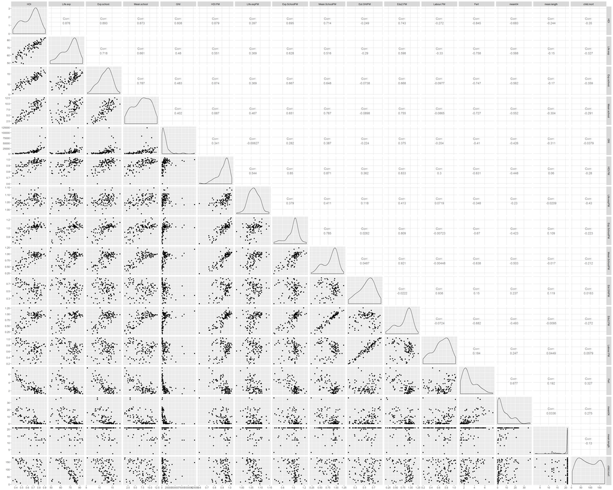

```r
#Removing incomplete rows and making a general picture of the dataset
comp <- complete.cases(hdi.aid)
hdi.aid$mean04[is.na(hdi.aid$mean04)] <- 0
hdi.aid2 <- hdi.aid
hdi.aid2$comp <- comp
hdi.aid2 <- filter(hdi.aid, comp==TRUE)
hdi.aid2 <- select(hdi.aid2, -comp)
hdi.aid21 <- select(hdi.aid2, -Country)
ggpairs(hdi.aid21)
```

From the distributions one can observe several clear correlations and some geometrical distributions as well as scatterplots which have no strong combining values. All in all, they are very varied.

Here are correlations of the variables:

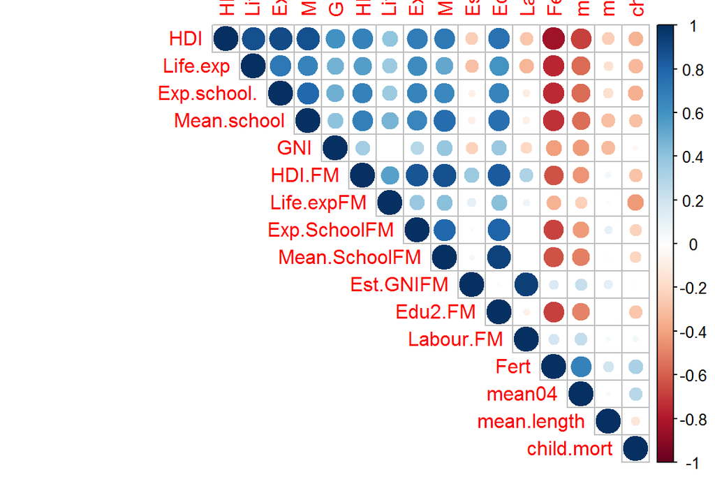

```r
#Removing incomplete rows and maikng a correlation matrix

corrplot(cor(hdi.aid2[2:17]), type="upper")
```

Now in this we can see that foreign aid correlates negatively with most things, except the fertility rate, which in this case means that the more a place has received foreign aid the higher the birth rate of women. Of course this follows, as the places that receive foreign aid usually need it. Also of interest is that the fertility rate is not very strongly correlated with GNI. To get this plot, the NA values had to be eliminated, which brings the amount of observations down. This removed the countries which do not receive aid from the data as well.

## Observing some correlations between variables of interest

Here is a linear regression fit of the variables GNI and Fert, where we use GNI as an explanatory variable and Fert as the dependent one.

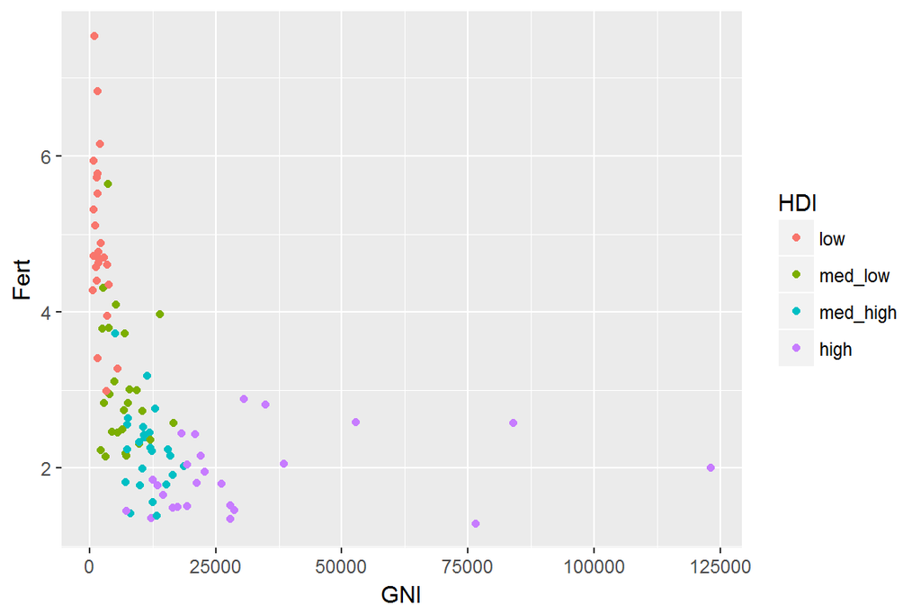

```r
#Removing incomplete rows
comp <- complete.cases(hdi.aid)
hdi.aid$mean04[is.na(hdi.aid$mean04)] <- 0
hdi.aid2 <- hdi.aid
hdi.aid2$comp <- comp
hdi.aid2 <- filter(hdi.aid, comp==TRUE)
hdi.aid2 <- dplyr::select(hdi.aid2, -comp)
names <- hdi.aid2$Country
hdi.aid2 <- dplyr::select(hdi.aid2, -Country)
#Converting HDI to a factor
bins <- quantile(hdi.aid2$HDI)
hdi_cat <- cut(hdi.aid2$HDI, breaks = bins, include.lowest = TRUE, label = c("low", "med_low", "med_high", "high"))
hdi.aid22 <- hdi.aid2
hdi.aid22$HDI <- hdi_cat
ggplot(hdi.aid22,
       aes(y = Fert, x = GNI, color=HDI, ylab="Birth rate")) +
  geom_point()
```

The plot has HDI coloring to go with. Of interest is that the distribution shows, that high GNI, while mostly guaranteeing low birth rate of women is not a prerequisite for it and whil low GNI seems to correlate with high birth rate, this is far from predetermined by it and the same seems to hold for HDI values as well, where a high HDI value means low birth rate, but especially a medium low HDI value does not mean high birth rate.

## Principal component analysis

So, to proceed with the analysis, principal component analysis calculates components, which cause the highest amount of variance in the variables which are under consideration.

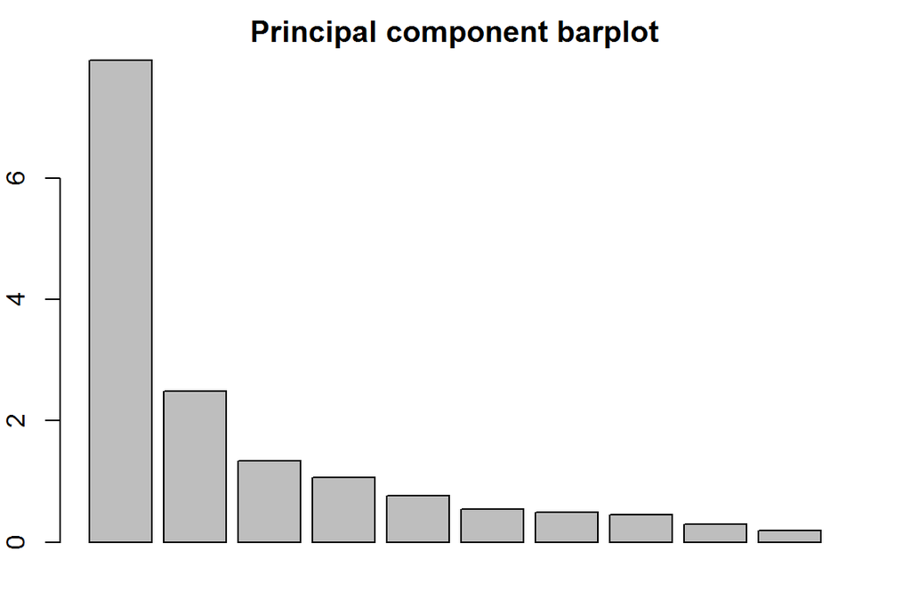

```r
#Caling the dataset. Then we proceed with pca and make a barplot of it.
hdiaid2_sc <- scale(hdi.aid2)
pca_hdi <- prcomp(hdiaid2_sc)
par(mar = rep(2, 4))
plot(pca_hdi, main = "Principal component barplot")
```

```r
pca_hdi
```

```
## Standard deviations:
##  [1] 2.81741991 1.57722360 1.15861300 1.03004890 0.87541025 0.73493525
##  [7] 0.69994715 0.67130592 0.54311307 0.43161006 0.40887115 0.36026319
## [13] 0.27072364 0.21974101 0.12397747 0.09435736
##
## Rotation:
##                       PC1          PC2         PC3         PC4         PC5
## HDI            0.33877923  0.127837171 -0.06769907  0.07253902  0.07202785
## Life.exp       0.29152556  0.165813049  0.04824680  0.07655878  0.07695871
## Exp.school.    0.30905471  0.017937478 -0.06605505  0.09803514  0.14051014
## Mean.school    0.31290658 -0.003362833 -0.11867589  0.13272923 -0.20080187
## GNI            0.18837236  0.208250700 -0.39154106 -0.08396337  0.38880919
## HDI.FM         0.29575364 -0.322176009 -0.02532781 -0.12305910 -0.01710935
## Life.expFM     0.17865858 -0.192782213  0.28502661  0.45352857 -0.39907375
## Exp.SchoolFM   0.29141376 -0.146550399  0.08807072 -0.30129512 -0.14673235
## Mean.SchoolFM  0.30231330 -0.147164219 -0.02789068 -0.25666462 -0.21033946
## Est.GNIFM     -0.04049423 -0.583112598 -0.20069955  0.09876484  0.22965898
## Edu2.FM        0.30934612 -0.105524130  0.03202222 -0.23515822 -0.21521078
## Labour.FM     -0.05381028 -0.561431639 -0.26915274  0.12660506  0.23162847
## Fert          -0.30659971 -0.071020777  0.01669762 -0.05380354 -0.11192529
## mean04        -0.24431503 -0.147497939 -0.06334437  0.03702793 -0.42616438
## mean.length   -0.05059247 -0.181437770  0.61177409 -0.49279256  0.29942415
## child.mort    -0.13836336  0.047803755 -0.48848097 -0.49891758 -0.34032010
##                        PC6          PC7          PC8         PC9
## HDI           -0.008972479  0.118162272 -0.075485396 -0.17776939
## Life.exp      -0.057259294  0.360288644 -0.443418765  0.22952153
## Exp.school.   -0.023169993  0.306695641 -0.006691749 -0.60493949
## Mean.school   -0.106525114 -0.016127073  0.228064977 -0.43241168
## GNI            0.634684807 -0.245817885 -0.227215685  0.05188387
## HDI.FM         0.096951120 -0.059071264 -0.097076195  0.11864880
## Life.expFM     0.090001816 -0.403044220 -0.500744724 -0.04448539
## Exp.SchoolFM   0.007240154  0.292722407 -0.076838763  0.23164652
## Mean.SchoolFM  0.132545570 -0.243880156  0.301078864  0.01004233
## Est.GNIFM     -0.070288068  0.045147214 -0.054027388  0.03182784
## Edu2.FM        0.141658431 -0.084642667  0.283459256  0.15539133
## Labour.FM     -0.088928662  0.036870979 -0.017281179 -0.01324042
## Fert           0.384052130 -0.152566405 -0.016860387 -0.37487671
## mean04         0.502636517  0.586142489 -0.034298083 -0.02169473
## mean.length    0.060699554 -0.001253268 -0.223572660 -0.30157691
## child.mort    -0.331769872 -0.113929041 -0.449736053 -0.18163219
```

[output cut: 19 more lines]

```
## Life.exp      -0.1422760765 -0.265292343  0.071682591
## Exp.school.   -0.0744545971 -0.202556667  0.106223182
## Mean.school    0.1803445172 -0.175215834  0.220464787
## GNI            0.0550959283 -0.149740818  0.002872054
## HDI.FM         0.0002513543  0.464249493  0.679031167
## Life.expFM    -0.0102766822 -0.075237266 -0.113238105
## Exp.SchoolFM   0.1356589119 -0.163753282 -0.228965076
## Mean.SchoolFM -0.4021529583 -0.230029541 -0.274357147
## Est.GNIFM      0.6008765323 -0.163964902 -0.206234487
## Edu2.FM        0.2058900228  0.012120141 -0.015660061
## Labour.FM     -0.5874105682  0.032742922 -0.088449950
## Fert           0.0610128365  0.045380980 -0.053533348
## mean04        -0.0582878469  0.066853528  0.008288261
## mean.length   -0.0253726292 -0.008515399 -0.017889778
## child.mort     0.0113524102  0.013792021 -0.009653576
```

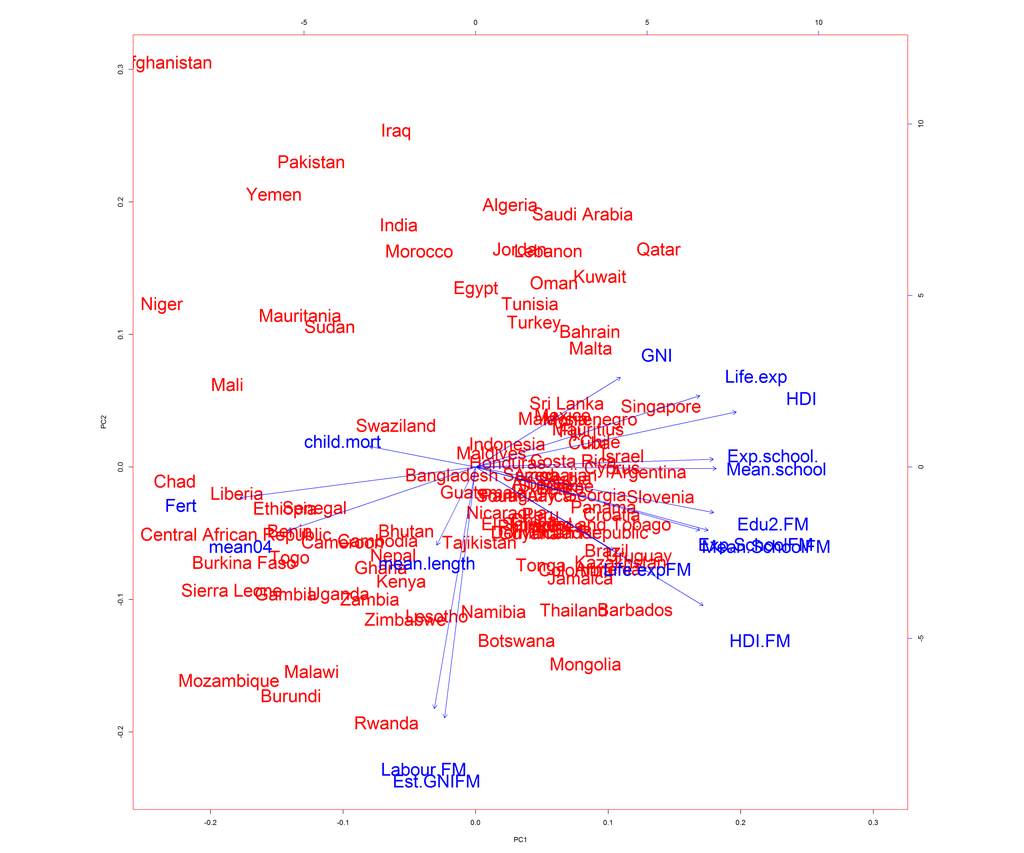

```r
#Making a biplot
biplot(pca_hdi, choices = 1:2, cex = c(2.5, 2.5), col = c("red", "blue"), xlabs = names)
```

The countries themselves vary greatly along the axises, if one does not take into account the cluster in the centre of the visualization. But what one can infer from this biplot is that the countries on the left side, which group according to the first and stronger component are many fewer than the majority of the countries, which cluster a bit on the right side of the image. When one takes into consideration, that all countries depicted here are recipients of foreign aid, or were at least between 1984 and 2004 and taking into account that the length in years of aid received was quite heavily biased towards the maximum value and that the proportion of GNI received as foreign aid was very widely distributed, one can be cautiously optimistic about the situation as depicted by the data.